# MechaCar Statistical Analysis Notebook

Note: This is a R Notebook which outputs a companion file MechaCarChallenge.nb.html when the Notebook is run.

### **Pre-requisite**

You will need R install on your computer and an IDE. R Studio is recommended. You should also install tidyverse with *install.packages(“tidyverse”)*. This will install the core tidyverse packages that you are likely to use in almost every analysis:

- [ggplot2](https://ggplot2.tidyverse.org/), for data visualisation.
- [dplyr](https://dplyr.tidyverse.org), for data manipulation.
- [tidyr](https://tidyr.tidyverse.org), for data tidying.
- [readr](https://readr.tidyverse.org/), for data import.
- [purrr](https://purrr.tidyverse.org/), for functional programming.
- [tibble](https://tibble.tidyverse.org), for tibbles, a modern re-imagining of data frames.

### **Deliverable 1: Linear Regression to Predict MPG**

The `MechaCar_mpg.csv` dataset contains mpg test results for 50 prototype MechaCars. The MechaCar prototypes were produced using multiple design specifications to identify ideal vehicle performance. Multiple metrics, such as vehicle length, vehicle weight, spoiler angle, drivetrain, and ground clearance, were collected for each vehicle.

```r
# 1a. Load the dplyr package
library(dplyr)
```

```r
# 1b. Load the tidyverse package
library(tidyverse)
```

```r
# 2. Import and read in the MechaCar_mpg.csv file as a dataframe.
mecha_mpg <- read.csv(file='./Resources/Data/MechaCar_mpg.csv',check.names=F,stringsAsFactors = F)
```

```r
# 3. Run linear regression on all six variables(i.e., columns), and add the dataframe as the data parameter.

lm(mpg ~ vehicle_length + vehicle_weight + spoiler_angle + ground_clearance + AWD, data=mecha_mpg)
```

```
Call:
lm(formula = mpg ~ vehicle_length + vehicle_weight + spoiler_angle +
    ground_clearance + AWD, data = mecha_mpg)

Coefficients:
     (Intercept)    vehicle_length    vehicle_weight     spoiler_angle  ground_clearance               AWD
      -1.040e+02         6.267e+00         1.245e-03         6.877e-02         3.546e+00        -3.411e+00
```

```r
# 4. Using the summary() function, determine the p-value and the r-squared value for the linear regression model.

summary(lm(mpg ~ vehicle_length + vehicle_weight + spoiler_angle + ground_clearance + AWD, data=mecha_mpg))
```

```
Call:
lm(formula = mpg ~ vehicle_length + vehicle_weight + spoiler_angle +
    ground_clearance + AWD, data = mecha_mpg)

Residuals:
     Min       1Q   Median       3Q      Max
-19.4701  -4.4994  -0.0692   5.4433  18.5849

Coefficients:
                   Estimate Std. Error t value Pr(>|t|)
(Intercept)      -1.040e+02  1.585e+01  -6.559 5.08e-08 ***
vehicle_length    6.267e+00  6.553e-01   9.563 2.60e-12 ***
vehicle_weight    1.245e-03  6.890e-04   1.807   0.0776 .
spoiler_angle     6.877e-02  6.653e-02   1.034   0.3069
ground_clearance  3.546e+00  5.412e-01   6.551 5.21e-08 ***
AWD              -3.411e+00  2.535e+00  -1.346   0.1852
---
Signif. codes:  0 ‘***’ 0.001 ‘**’ 0.01 ‘*’ 0.05 ‘.’ 0.1 ‘ ’ 1

Residual standard error: 8.774 on 44 degrees of freedom
Multiple R-squared:  0.7149,    Adjusted R-squared:  0.6825
F-statistic: 22.07 on 5 and 44 DF,  p-value: 5.35e-11
```

```r
# Optional Steps: Remove the independent variables that have little impact on predicting mpg to see impact

lm(mpg ~ vehicle_length + ground_clearance, data=mecha_mpg)
```

```
Call:
lm(formula = mpg ~ vehicle_length + ground_clearance, data = mecha_mpg)

Coefficients:
     (Intercept)    vehicle_length  ground_clearance
         -91.557             6.081             3.567
```

```r
summary(lm(mpg ~ vehicle_length + ground_clearance, data=mecha_mpg))
```

```
Call:
lm(formula = mpg ~ vehicle_length + ground_clearance, data = mecha_mpg)

Residuals:
    Min      1Q  Median      3Q     Max
-17.493  -7.705   1.344   6.642  18.500

Coefficients:
                 Estimate Std. Error t value Pr(>|t|)
(Intercept)      -91.5573    13.9649  -6.556 3.86e-08 ***
vehicle_length     6.0811     0.6732   9.033 7.68e-12 ***
ground_clearance   3.5669     0.5401   6.604 3.26e-08 ***
---
Signif. codes:  0 ‘***’ 0.001 ‘**’ 0.01 ‘*’ 0.05 ‘.’ 0.1 ‘ ’ 1

Residual standard error: 9.078 on 47 degrees of freedom
Multiple R-squared:  0.674, Adjusted R-squared:  0.6601
F-statistic: 48.59 on 2 and 47 DF,  p-value: 3.637e-12
```

### **Deliverable 2: Create Visualizations for the Trip Analysis**

The MechaCar `Suspension_Coil.csv` dataset contains the results from multiple production lots. In this dataset, the weight capacities of multiple suspension coils were tested to determine if the manufacturing process is consistent across production lots.

```r
#2. Import and read in the Suspension_Coil.csv file as a table
mecha_coil <- read.csv(file='./Resources/Data/Suspension_Coil.csv',check.names=F,stringsAsFactors = F)
```

```r
# 2. Create a total_summary dataframe in order to derive mean, median, variance, and standard deviation of the suspension coil’s PSI column

total_summary <- mecha_coil %>% summarize(Mean_PSI=mean(PSI),
                                          Median_PSI=median(PSI),
                                          Var_PSI=var(PSI),
                                          Std_Dev_PSI=sd(PSI),
                                          Num_Coil=n(), .groups = 'keep')
```

```r
# 3. Create a lot_summary dataframe in order to to group each manufacturing lot by the mean, median, variance, and standard deviation of the suspension coil’s PSI column.

lot_summary <- mecha_coil  %>% group_by(Manufacturing_Lot) %>% summarize(Mean_PSI=mean(PSI),
                                          Median_PSI=median(PSI),
                                          Var_PSI=var(PSI),
                                          Std_Dev_PSI=sd(PSI),
                                          Num_Coil=n(), .groups = 'keep')
```

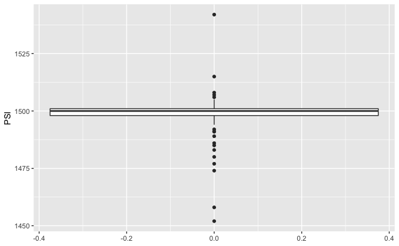

```r
# 4a. Graph Box plot PSI Whole lot
plt1 <- ggplot(mecha_coil,aes(y=PSI)) #import dataset into ggplot2
plt1 + geom_boxplot() #add boxplot
```

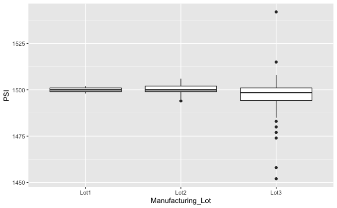

```r
# 4b. Graph box plot: PSI each individual Lot
plt2 <- ggplot(mecha_coil,aes(x=Manufacturing_Lot,y=PSI)) #import dataset into ggplot2
plt2 + geom_boxplot()
```

### **Deliverable 3: T-Tests on Suspension Coils**

Perform t-tests to determine if all manufacturing lots and each lot individually are statistically different from the population mean of 1,500 pounds per square inch.

```r
# 1. Use the t.test() function to determine if the PSI across all manufacturing lots is statistically different from the population mean of 1,500 pounds per square inch.

t.test(mecha_coil$PSI,mu=1500)
```

[output not shown]

```r
# 2. Use the t.test() function and its subset() argument to determine if the PSI for each manufacturing lot is statistically different from the population mean of 1,500 pounds per square inch.

# create the functions
lot1 <- subset(mecha_coil, Manufacturing_Lot=="Lot1")
lot2 <- subset(mecha_coil, Manufacturing_Lot=="Lot2")
lot3 <- subset(mecha_coil, Manufacturing_Lot=="Lot3")

# envoke the functions
t.test(lot1$PSI,mu=1500)
```

```
    One Sample t-test

data:  lot1$PSI
t = 0, df = 49, p-value = 1
alternative hypothesis: true mean is not equal to 1500
95 percent confidence interval:
 1499.719 1500.281
sample estimates:
mean of x
     1500
```

```r
t.test(lot2$PSI,mu=1500)
```

```
    One Sample t-test

data:  lot2$PSI
t = 0.51745, df = 49, p-value = 0.6072
alternative hypothesis: true mean is not equal to 1500
95 percent confidence interval:
 1499.423 1500.977
sample estimates:
mean of x
   1500.2
```

```r
t.test(lot3$PSI,mu=1500)
```

```
    One Sample t-test

data:  lot3$PSI
t = -2.0916, df = 49, p-value = 0.04168
alternative hypothesis: true mean is not equal to 1500
95 percent confidence interval:
 1492.431 1499.849
sample estimates:
mean of x
  1496.14
```